# Lecture 2: Intro to Data Analytics

## Interlude: How R thinks about data & Accessing data in a DataFrame

We mentioned that R stores data in data frames, which you might think of as a type of spreadsheet. Each row is a different observation (a different respondent) and each column is a different variable (the first is genhlth, the second exerany and so on). We can see the size of the data frame next to the object name in the workspace or we can type dim(cdc) which will return the number of rows and columns.

```r
dim(cdc)
```

```
## [1] 20000     9
```

Now, if we want to access a subset of the full data frame, we can use row-and-column notation. For example, to see the sixth variable of the 567th respondent (row=567, col = 6), use the format

```r
cdc[567,6]
```

```
## [1] 160
```

which means we want the element of our data set that is in the 567th row (meaning the 567th person or observation) and the 6th column (in this case, weight). We know that weight is the 6th variable because it is the 6th entry in the list of variable names.

```r
names(cdc)
```

```
## [1] "genhlth"  "exerany"  "hlthplan" "smoke100" "height"   "weight"   "wtdesire"
## [8] "age"      "gender"
```

```r
cdc[5:10,6]
```

```
## [1] 150 114 194 170 150 180
```

```r
cdc[c(5,10,15,20),7:8]
```

```
##    wtdesire age
## 5       130  55
## 10      170  44
## 15      170  23
## 20      120  33
```

```r
1:10
```

```
##  [1]  1  2  3  4  5  6  7  8  9 10
```

```r
cdc[1:10,6]
```

```
##  [1] 175 125 105 132 150 114 194 170 150 180
```

As a rule, we omit the column number to see all columns in a data frame. Similarly, if we leave out an index or range for the rows, we would access all the observations, not just the 567th, or rows 1 through 10.

Try the following to see the weights for all 20,000 respondents fly by on your screen Z(But will stop reaching the display limit).

```r
yy = cdc[,6]
```

REMEMBER: The comma is very important in the Dataframe data selection

Now Recall that column 6 represents respondents weight, so the command above reported all of the weights in the data set. An alternative method to access the weight data is by referring to the name. Previously, we typed names(cdc) to see all the variables contained in the cdc data set. We can use any of the variable names to select items in our data set.

```r
xxx = cdc$weight   ## Looking at only one specific column.  Same as the above statement
                  ## Notice the $ symbol
```

The dollar-sign tells R to look in data frame cdc for the column called weight. Since that’s a single vector.

Now we can subset it with just a single index inside square brackets. We see the weight for the 567th respondent by typing.

```r
cdc$weight[567]## WHY DO WE NOT HAVE ANY COMMA HERE??????
```

```
## [1] 160
```

```r
#same as
cdc[567,6]  #  Similarly, for just the first 10 respondents
```

```
## [1] 160
```

```r
cdc$weight[1:10]  ## WHY DO WE NOT HAVE ANY COMMA HERE??????
```

```
##  [1] 175 125 105 132 150 114 194 170 150 180
```

The command above returns the same result as the cdc[1:10,6] command. Both row-and-column notation and dollar-sign notation are widely used, which one you choose to use depends on your personal preference.

A little more on subsetting It’s often useful to extract all individuals (cases) in a data set that have specific characteristics. We accomplish this through conditioning commands. First, consider expressions like:

```r
xxx = cdc$gender == "m"
# or
yy = cdc$age > 30
```

REMEMBER These commands produce a series of TRUE and FALSE values.

There is one value for each respondent, where TRUE indicates that the person was male (via the first command) or older than 30 (second command).

NOW - Suppose we want to extract just the data for the men in the sample, or just for those over 30. We can use the R function – subset() – to do that for us. For example, the command:

```r
mdata <- subset(cdc, cdc$gender == "m")
Over30Data = subset(cdc, cdc$age > 30)
barplot(table(cdc$smoke100))
```

[output not shown]

```r
xxx<- subset(cdc, cdc$gender == "m" & cdc$age > 30)
```

Will create a new data set called mdata that contains only the men from the cdc data set.

In addition to finding it in your workspace alongside its dimensions, you can take a peek at the first several rows as usual

```r
head(mdata)
```

```
##      genhlth exerany hlthplan smoke100 height weight wtdesire age gender
## 1       good       0        1        0     70    175      175  77      m
## 7  very good       1        1        0     71    194      185  31      m
## 8  very good       0        1        0     67    170      160  45      m
## 10      good       1        1        0     70    180      170  44      m
## 11 excellent       1        1        1     69    186      175  46      m
## 12      fair       1        1        1     69    168      148  62      m
```

```r
dim(mdata)
```

```
## [1] 9569    9
```

This new data set contains all the same variables but just under half the rows. It is also possible to tell R to keep only specific variables, which is a topic we’ll discuss in a future lab.

For now, the important thing is that we can carve up the data based on values of one or more variables.

Subsetting a dataframe with multiple conditions.

As an aside, you can use several of these conditions together with (and) & and (or) |. The & is read “and” so that

```r
##  Note the == to check for equality.  (= is an assignmnt . same as <-  )
m_and_over30 <- subset(cdc, gender == "m" & age > 30)
head(m_and_over30)
```

```
##      genhlth exerany hlthplan smoke100 height weight wtdesire age gender
## 1       good       0        1        0     70    175      175  77      m
## 7  very good       1        1        0     71    194      185  31      m
## 8  very good       0        1        0     67    170      160  45      m
## 10      good       1        1        0     70    180      170  44      m
## 11 excellent       1        1        1     69    186      175  46      m
## 12      fair       1        1        1     69    168      148  62      m
```

```r
m_or_over30 <- subset(cdc, gender == "m" | age > 30)
head(m_or_over30, 25)
```

```
##      genhlth exerany hlthplan smoke100 height weight wtdesire age gender
## 1       good       0        1        0     70    175      175  77      m
## 2       good       0        1        1     64    125      115  33      f
## 3       good       1        1        1     60    105      105  49      f
## 4       good       1        1        0     66    132      124  42      f
## 5  very good       0        1        0     61    150      130  55      f
## 6  very good       1        1        0     64    114      114  55      f
## 7  very good       1        1        0     71    194      185  31      m
## 8  very good       0        1        0     67    170      160  45      m
## 10      good       1        1        0     70    180      170  44      m
## 11 excellent       1        1        1     69    186      175  46      m
## 12      fair       1        1        1     69    168      148  62      m
## 13 excellent       1        0        1     66    185      220  21      m
## 14 excellent       1        1        1     70    170      170  69      m
## 15      fair       1        0        0     69    170      170  23      m
## 16      good       1        1        1     73    185      175  79      m
## 17      good       0        0        1     67    156      150  47      m
## 18      fair       0        1        1     71    185      185  76      m
## 19      good       1        1        1     75    200      190  43      m
## 20 very good       1        1        0     67    125      120  33      f
## 21 very good       1        1        0     69    200      150  48      f
## 22      good       1        1        1     65    160      140  54      f
## 23 very good       0        1        1     73    160      160  43      m
## 24      good       1        1        1     67    165      158  30      m
## 26      good       0        1        0     68    190      150  33      f
## 27 excellent       1        0        1     67    190      165  44      f
```

### EXERCISE: Try this Out.

How do we create a new object called under23_and_smoke that contains all observations of respondents under the age of 23 that have smoked 100 cigarettes in their lifetime. Write the command you used to create the new object as the answer to this exercise.

```r
under23_and_smoke <- subset(cdc, age < 23 & smoke100 == 1)
head(under23_and_smoke)
```

```
##       genhlth exerany hlthplan smoke100 height weight wtdesire age gender
## 13  excellent       1        0        1     66    185      220  21      m
## 37  very good       1        0        1     70    160      140  18      f
## 96  excellent       1        1        1     74    175      200  22      m
## 180      good       1        1        1     64    190      140  20      f
## 182 very good       1        1        1     62     92       92  21      f
## 240 very good       1        0        1     64    125      115  22      f
```

### Quantitative data

With our subsetting tools in hand, Let us make basic summaries of the BRFSS questionnaire. We’ve already looked at categorical data such as smoke and gender so now let’s turn our attention to quantitative data.

Two common ways to visualize quantitative data are with box plots and histograms.

We can construct a box plot for a single variable with the following command.

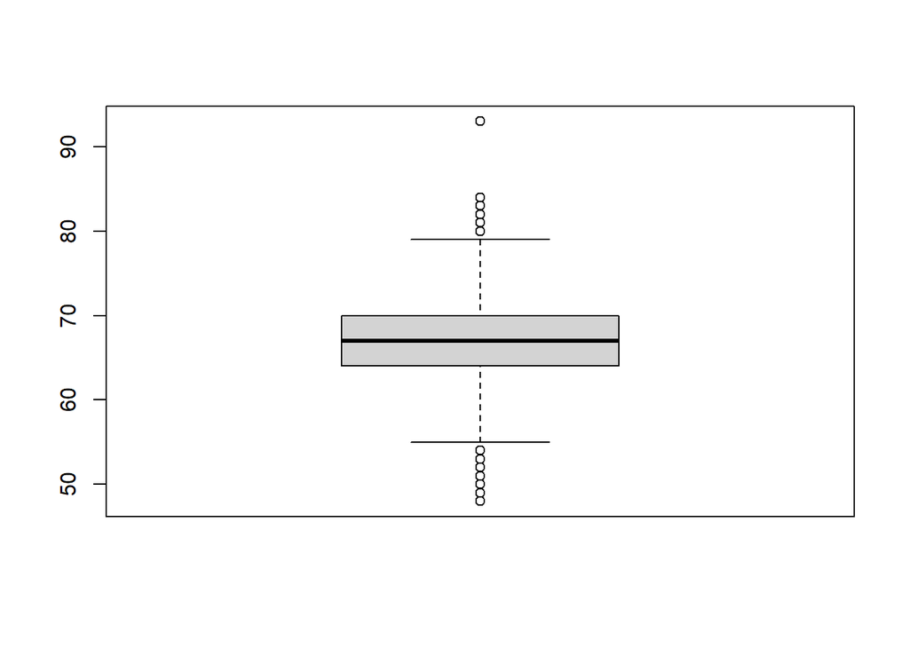

```r
boxplot(cdc$height)
```

```r
summary(cdc$height)
```

```
##    Min. 1st Qu.  Median    Mean 3rd Qu.    Max.
##   48.00   64.00   67.00   67.18   70.00   93.00
```

Confirm that the median and upper and lower quartiles reported in the numerical summary match those in the graph.

The purpose of a boxplot is to provide a thumbnail sketch of a variable for the purpose of comparing across several categories.

So we can, for example, compare the heights of men and women with:

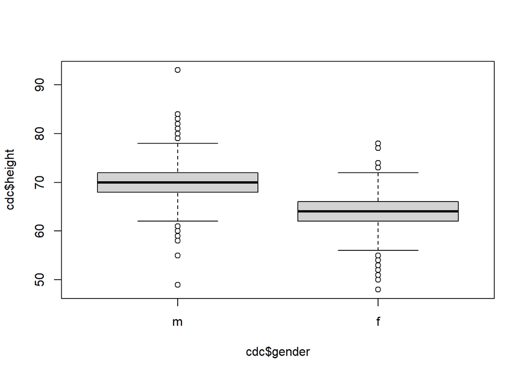

```r
boxplot(cdc$height ~ cdc$gender)
```

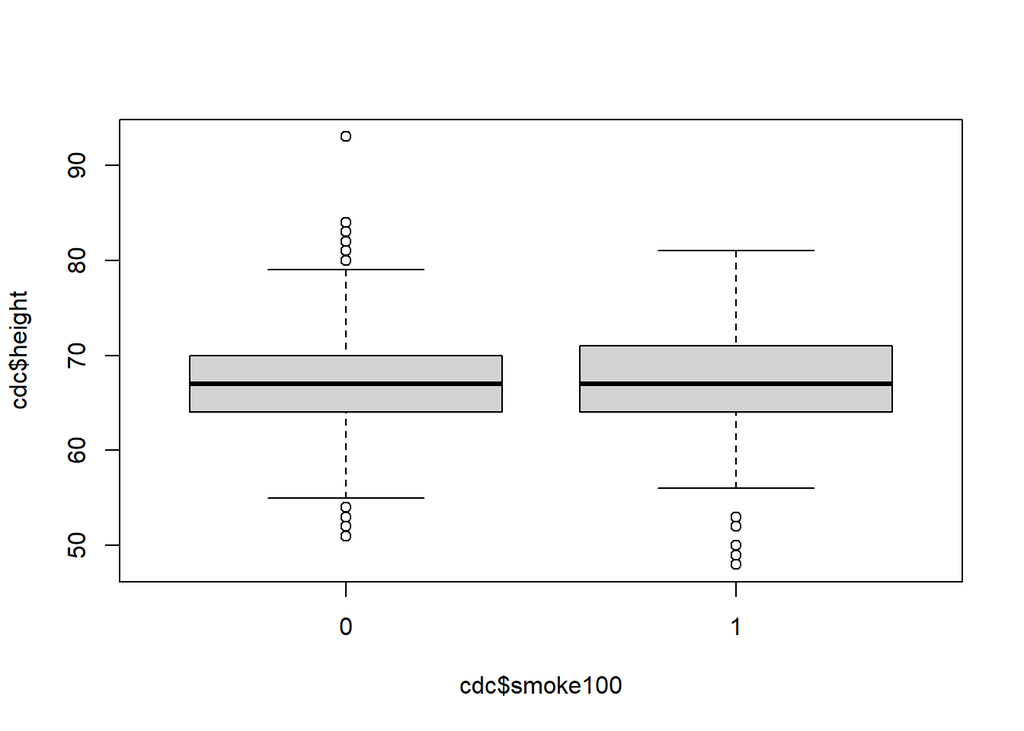

```r
boxplot(cdc$height ~ cdc$smoke100)
```

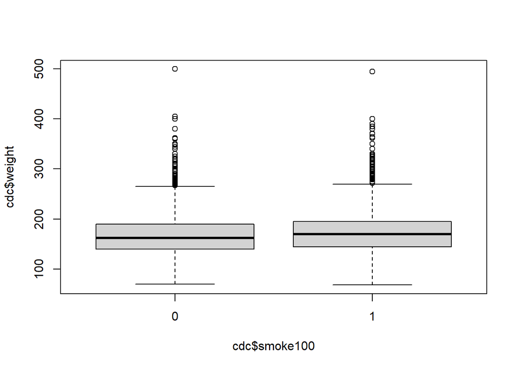

```r
boxplot(cdc$weight ~ cdc$smoke100) ## The notation ~ here is new.
```

The ~ character can be read versus or as a function of. So we’re asking R to give us a box plots of heights where the groups are defined by gender.

Next let’s consider a new variable that doesn’t show up directly in this data set: Body Mass Index (BMI) (http://en.wikipedia.org/wiki/Body_mass_index). BMI is a weight to height ratio and can be calculated as:

All You Workout addicts will know it:

[ BMI = ( {weight~(lb)} divided by {height~(in)^2}) * 703 ]

703 is the approximate conversion factor to change units from metric (meters and kilograms) to imperial (inches and pounds).

The following two lines first make a new object called bmi and then creates box plots of these values, defining groups by the variable cdc$genhlth.

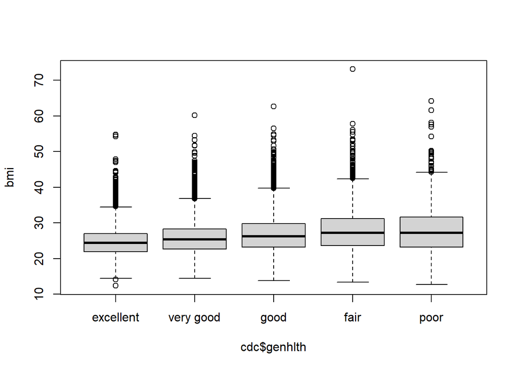

```r
bmi <- (cdc$weight / cdc$height^2) * 703
boxplot(bmi ~ cdc$genhlth) #Rplot11
```

Notice that the first line above is just some arithmetic, but it’s applied to all 20,000 numbers in the cdc data set. That is, for each of the 20,000 participants, we take their weight, divide by their height-squared and then multiply by 703.The result is 20,000 BMI values, one for each respondent. This is one reason why we like R: It lets us perform computations like this using very simple expressions.

4. What does this box plot show? Pick another categorical variable from the data set and see how it relates to BMI.

List the variable you chose, why you might think it would have a relationship to BMI, and indicate what the figure seems to suggest.

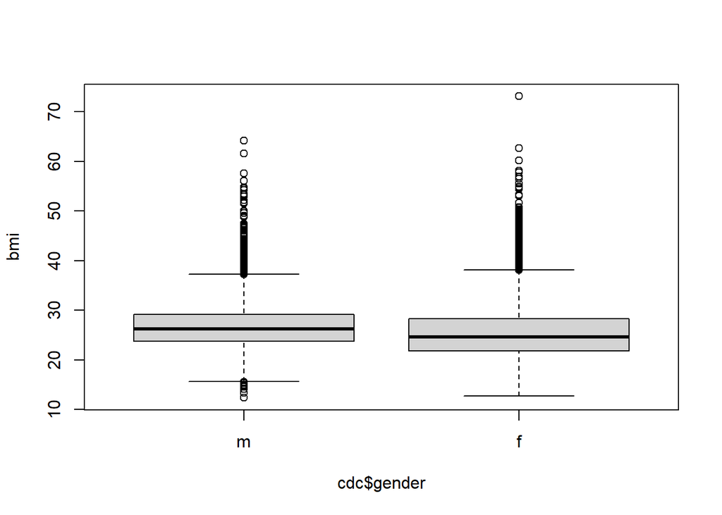

```r
boxplot(bmi ~ cdc$gender)
```

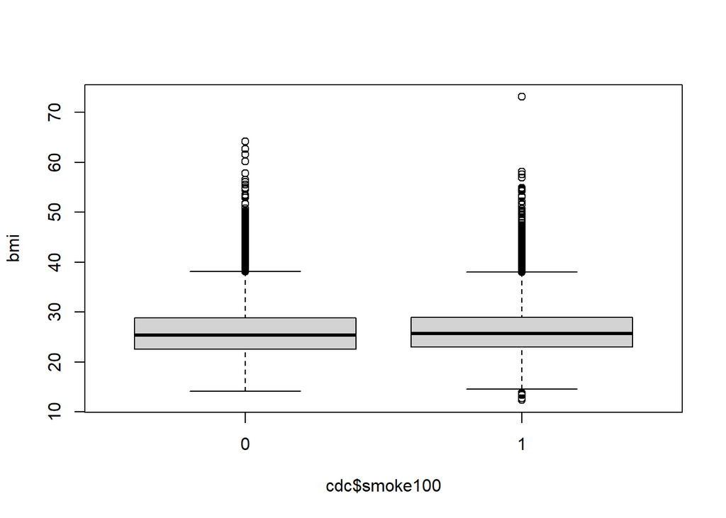

```r
boxplot(bmi ~ cdc$smoke100)
```

Finally: ### Data Visualization – let’s make some histograms. We can look at the histogram for the age of our respondents with command

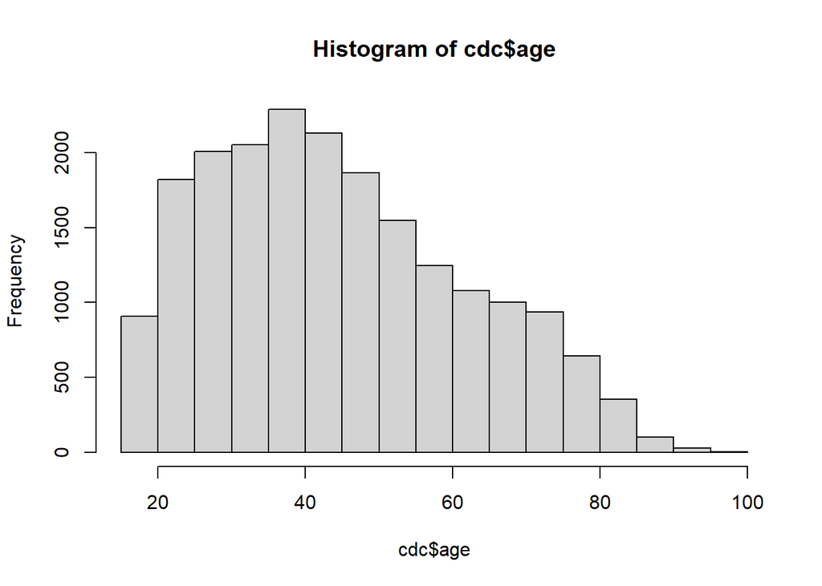

```r
hist(cdc$age)
```

Histograms are generally a very good way to see the shape of a single distribution, but that shape can change depending on how the data is split between the different bins. You can control the number of bins by adding an argument to the command.